# Day 1: Introduction and Motivation

Aaron R. Williams

# Introductions

- Synthetic data validation
- [Projects that iterate with R Markdown](https://www.urban.org/policy-centers/cross-center-initiatives/state-and-local-finance-initiative/projects/state-fiscal-briefs)
- Manage the Urban Institute ggplot2 theme ([Examples](https://urbaninstitute.github.io/r-at-urban/graphics-guide.html)) ([Code](https://github.com/UrbanInstitute/urbnthemes))

*Data visualization is fundamental to data analysis and data communication*

# Outline

1. Introductions and Motivation
2. Grammar of Graphics
3. Some Data Viz Theory
4. Jon Schwabish’s Five Guidelines for Better Data Visualizations

Additional topics:

- Data munging for data visualization
- Big Data
- Mapping
- Visualization and regression models

# Why `ggplot2`

### 1. Looks good!

`library(ggplot2)` is used by [fivethirtyeight](https://fivethirtyeight.com/features/the-56-best-and-weirdest-charts-we-made-in-2019/), [Financial Times](https://johnburnmurdoch.github.io/slides/r-ggplot/#/), [BBC](https://bbc.github.io/rcookbook/), the [Urban Institute](https://urbaninstitute.github.io/r-at-urban/graphics-guide.html), and more.

### 2. Flexible and expressive

By breaking data visualization into component parts, `library(ggplot2)` is a set of building blocks instead of a set of rigid cookie cutters.

### 3. Reproducible

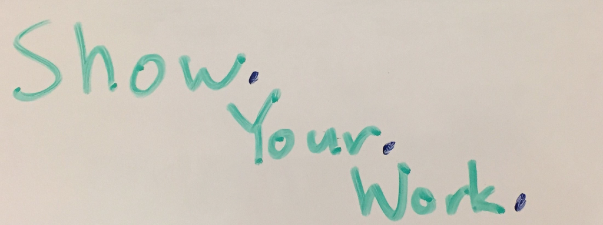

### 4. Scalable

It’s almost as easy to make the 100th chart as it is to make the 2nd chart. This allows for [iteration](https://www.urban.org/policy-centers/cross-center-initiatives/state-and-local-finance-initiative/projects/state-fiscal-briefs).

### 5. In my analysis workflow

[figure not shown]

Data visualization is fundamental to EDA, statistical modeling, and basically any work with data. Too many people find themselves using different tools for data visualization and statistical modeling. R/ggplot2 allows everything to happen in the same script at the same time.

# R Markdown

- [R Studio Tutorial](https://rmarkdown.rstudio.com/lesson-1.html)

This short course will rely on R Markdown, which is a literate statistical programming framework that combines text and images, code, and code output into output documents like PDFs and web pages. It is like an easier-to-use LaTeX with more flexibility. Instead of .R scripts, we will use .Rmd scripts.

1. Markdown
2. YAML Header
3. Code chunks

### Running code in documents

We will mostly run code inside of .Rmd documents.

1. Run the code like a .R script
2. Run the entire current chunk
3. Run all chunks above

### Knitting documents

More commonly, documents are knitted. This runs all of the code in the .Rmd in a new R session and then creates an output document like a .html or a .pdf. If the code has errors, knitting will fail.

### Exercise 1

Step 1: Open RStudio by double-clicking `sdss2021_data-viz-training.Rproj`

Step 2: Open `02_workbook.Rmd` in RStudio. Make sure it is in the `.Rproj`.

Step 3: Click knit!